# Cousera-Data-Science-Capstone

Hiroshi Kamijo

2020/07/14

## Introduction

This is Milestone Report for Data Science Capstone project from Coursera Data Science Specialization. The Objective of this report is to analyze text of blogs, news and twitter in the US.

## Set Up

First, loading necessary package and data set.

```r
library(ggplot2)
library(NLP)
library(tm)
library(RWeka)
blog <- readLines("en_US/en_US.blogs.txt",skipNul = TRUE, warn = TRUE)
news <- readLines("en_US/en_US.news.txt",skipNul = TRUE, warn = TRUE)
twitter <- readLines("en_US/en_US.twitter.txt",skipNul = TRUE, warn = TRUE)
```

## Subsampling

Three text data are very large, so I sample subet to make it easy to handle. I sample 1000 entries from each data.

```r
set.seed(0)
sample_size = 1000

sampled_blog <- blog[sample(1:length(blog),sample_size)]
sampled_news <- news[sample(1:length(news),sample_size)]
sampled_twitter <- twitter[sample(1:length(twitter),sample_size)]
```

```r
head(sampled_blog)
```

```
## [1] "It wasn't a \"rebellion\". The Mﾃｩtis were not \"insurgents\". They never were subjects of the British Crown, no one \"rebels\" against something they have never been a part of to begin with. They were free human beings living on their own land as the Creator / creation intended. Their ances…
## [2] "The majority of our presents have been furniture or electronics. One of these were a little more beneficial then either of us could have ever imagined."
## [3] "04 Toot, Toot, Tootsie (Styne, Green, Cahn) 04:22"
## [4] "Motherhood and certainly labor itself is nothing if not a test of strength, courage and endurance, so maintaining your fitness program, or even starting one sometime well before the doctor says, 窶弃ush!窶\x9d may be in your best interest. But many women find safely navigating the challenges a …
## [5] "So, I added some bling and also Stickled the butterflies. I probably should have heat set the ink or embossed the image before adding the Stickles. It seems that the red ink actually bled slightly once I added the Stickles. I use Stickles a lot, and I've never had a problem with my ink bleed…
## [6] "When I opened the door to let the dog out,"
```

```r
head(sampled_news)
```

```
## [1] "\"RACHEL Getting Married,\" a new movie from director Jonathan Demme and starring Anne Hathaway, opened this month and quickly became a surprise hit. In the film, Hathaway plays a recovering drug addict who's released from rehab to join her sister's raucous Connecticut wedding."
## [2] "Light, simple, and relying heavily on stove-top and cold preparation, crab might make a nice early Thanksgiving menu for those who must shuttle between families. It could also work for families like mine who eat late and want a snack but must keep the oven free for the hated bird."
## [3] "After a gorgeous reading of \"Free Fallin,\" the vintage Fleetwood Mac tune \"Oh Well\" provided a nice detour for the set, with Campbell turning in a torrid solo. Another nice surprise was a relative obscurity from the Heartbreakers' \"Live Anthology\" set, \"Drivin' Down to Georgia.\""
## [4] "Yost said in a statement that \"the majority of fiscal officers and treasurers do an exceptional job for taxpayers\" but some have taken advantage of their positions 窶\x93 and not just in charter schools."
## [5] "Some mourners wanted to open the coffin so they could see Rabbani's face, but his family did not allow it."
## [6] "After-school clubs, such as popular robotics programs, have been a major source of science experiences for state students and a good way for business to get involved with boosting science education, Renfro said."
```

```r
head(sampled_twitter)
```

```
## [1] "Shout out to our pals at We dig their tasty beverages! Anybody have a fave flavor? Stop by 739 SW 10th this week to try one!"
## [2] "I find out if I got into UF on Friday at 6:00 PM so this week needs to go by fast."
## [3] "Dear can you please have on your show!?!?!? They're are awesome! Funny! & Extremely gorgeous! You'd love em! <3"
## [4] "ooh, lol i'm such a fail .. thanks !(:"
## [5] "LOL.Give me a reason why you hate them and saying they can't sing or they're ugly isn't a reason."
## [6] "Johnny Depp was house shopping in Peterborough, NH. Gotta love my hometown."
```

Combining three data.

```r
sampled_data <- rbind(sampled_blog,sampled_news,sampled_twitter)
```

## Cleaning Data

This text data is including annoying data for analyzing. For example, punctuation, whitespace, discard and uppercases. So I convert this data. Fisrt, removing punctuation, second, removing whitespace, third, converting uppercase to lowercase, finally, removing numbers

```r
corpus<-VCorpus(VectorSource(sampled_data))
corpus <- tm_map(corpus, removePunctuation) # remove punctuation
corpus <- tm_map(corpus, stripWhitespace) # remove whitespace
corpus <- tm_map(corpus, content_transformer(tolower)) # convert to lowercase
corpus <- tm_map(corpus, removeNumbers) # remove numbers
changetospace <- content_transformer(function(x, pattern) gsub(pattern, " ", x))
corpus <- tm_map(corpus, changetospace, "/|@|\\|")
```

## N-grams

We use NGramTokenizer for this analysis. In this project, we analyze unigram, bigram, and trigram.

```r
uniGramTokenizer <- function(x) NGramTokenizer(x, Weka_control(min = 1, max = 1))
biGramTokenizer <- function(x) NGramTokenizer(x, Weka_control(min = 2, max = 2))
triGramTokenizer <- function(x) NGramTokenizer(x, Weka_control(min = 3, max = 3))


uniGM <- TermDocumentMatrix(corpus, control = list(tokenize = uniGramTokenizer))
biGM <- TermDocumentMatrix(corpus, control = list(tokenize = biGramTokenizer))
triGM <- TermDocumentMatrix(corpus, control = list(tokenize = triGramTokenizer))
```

## Generate n-gram histograms

Plotting unigram historam.

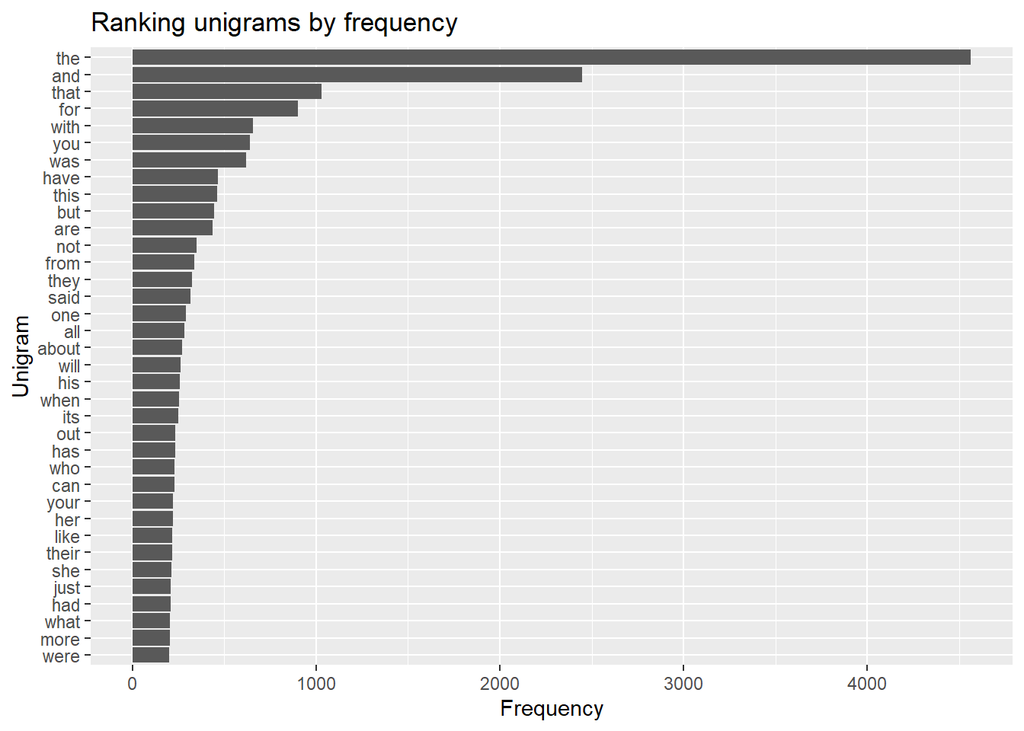

```r
freqTerms <- findFreqTerms(uniGM, lowfreq = 200)
termFreq <- rowSums(as.matrix(uniGM[freqTerms,]))
termFreq <- data.frame(unigram=names(termFreq), frequency=termFreq)

g1 <- ggplot(termFreq, aes(x=reorder(unigram, frequency), y=frequency)) +
    geom_bar(stat = "identity") +  coord_flip() +
    theme(legend.title=element_blank()) +
    xlab("Unigram") + ylab("Frequency") +
    labs(title = "Ranking unigrams by frequency")
print(g1)
```

Plotting bigram historam.

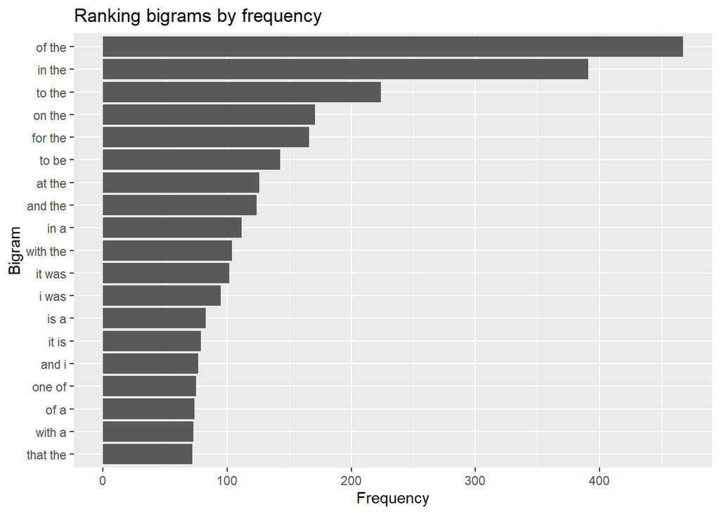

```r
freqTerms <- findFreqTerms(biGM, lowfreq = 70)
termFreq <- rowSums(as.matrix(biGM[freqTerms,]))
termFreq <- data.frame(bigram=names(termFreq), frequency=termFreq)

g2 <- ggplot(termFreq, aes(x=reorder(bigram, frequency), y=frequency)) +
    geom_bar(stat = "identity") +  coord_flip() +
    theme(legend.title=element_blank()) +
    xlab("Bigram") + ylab("Frequency") +
    labs(title = "Ranking bigrams by frequency")
print(g2)
```

Plotting trigram historam.

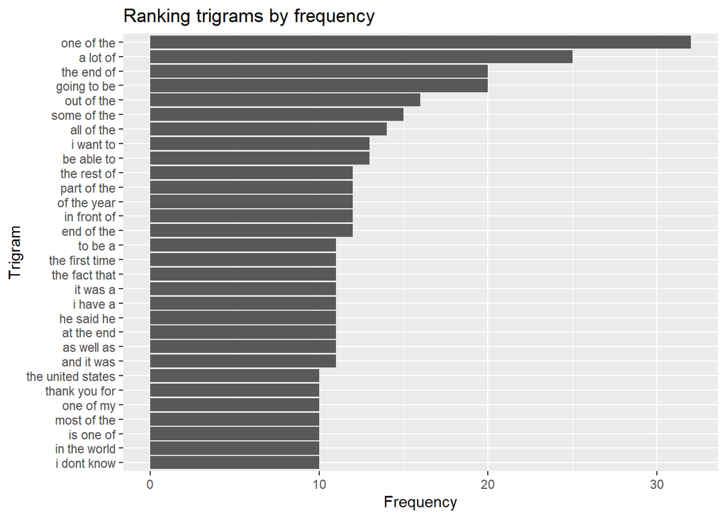

```r
freqTerms <- findFreqTerms(triGM, lowfreq = 10)
termFreq <- rowSums(as.matrix(triGM[freqTerms,]))
termFreq <- data.frame(trigram=names(termFreq), frequency=termFreq)

g3 <- ggplot(termFreq, aes(x=reorder(trigram, frequency), y=frequency)) +
    geom_bar(stat = "identity") +  coord_flip() +
    theme(legend.title=element_blank()) +
    xlab("Trigram") + ylab("Frequency") +
    labs(title = "Ranking trigrams by frequency")
print(g3)
```

## Conclusion

I use N-gram for analyzing text. We can see frequency of each units of one word, two words, and three words. Next, I will create shiny app to predict with this analysis.